# Visualizations of HackerRank Survey Data

By Michael A. Madaio, for the United Nations University, Institute on Computing and Society  
August, 2018

## Overview

Online developer communities boast millions of users - over 29 million on GitHub and over 8 million on Stack Overflow, in 2018. Participation in these communities is becoming one of the primary ways software developers learn new programming languages, improve their skills, develop collaborative projects, and find new job opportunities. [1] [2] [3]

Developers on these sites may ask and answer coding questions to improve their skills (e.g. Stack Overflow), use those skills to contribute to open-source code (e.g. GitHub) and participate in coding challenges (e.g. HackerRank). These platforms are becoming increasingly important to hiring decisions, as recruiters look at GitHub contributions or reputation on Stack Overflow as indicators of developers' skill.

However, despite the promise for these online developer communities to support software developers in their professional development, there are indicators that there may be serious difference in women and men's participation in these communities - differences which may further exacerbate existing gender gaps in the ICT workforce writ large.

## Research questions

To understand the extent and nature of the gender gap in online software developer communities, we ask the following research questions:

1. How do male and female developers differ in their participation in online software developer communities?
2. How do male and female developers differ in their perceptions of belonging and welcomingness in online software developer communities?
3. How do male and female developers in online software developer communities differ in their employment and prior experience with coding?

## Usage

In this notebook, we only use data from the HackerRank community survey.

- HackerRank [survey](https://www.kaggle.com/hackerrank/developer-survey-2018/home) (download latest survey results [here](https://www.kaggle.com/hackerrank/developer-survey-2018/))

We generate cross-tabulation heatmaps and generate country-level maps of response percentages.

## Overview

#### Gender Breakdown

#### Country Rankings

#### Age and Years of Coding Experience

#### Education

#### Industry

#### Job Level

#### Hiring Managers

## 1. Setup

These lines import the necessary package dependencies.

```python
import pandas as pd
import numpy as np
import os
import csv
import matplotlib.pyplot as plt
import pandas.tools.plotting
import seaborn as sns
import matplotlib
%matplotlib inline

# Install "fuzzywuzzy" and "python-Levenshtein" using pip install
from fuzzywuzzy import fuzz
from fuzzywuzzy import process

plt.style.use('seaborn')


import plotly.offline as offline
offline.init_notebook_mode(True)
import plotly.graph_objs as go
#plt.style.use('ggplot')
pd.options.display.max_rows =300
plt.rc('ytick',labelsize=12)
plt.rc('ytick',labelsize=12)
plt.rc('axes',labelsize=12)
```

```python
## Define folder paths

output_folder = "analysis-output"

if not os.path.exists(output_folder):
    os.makedirs(output_folder)

save_images = output_folder + "\plots"
save_maps = output_folder + "\maps"

if not os.path.exists(save_images):
    os.makedirs(save_images)

if not os.path.exists(save_maps):
    os.makedirs(save_maps)
```

These lines define the relative paths to folders for data and outputs.

### 1.0. Load data

Make sure all the survey data is saved to your data folder.  
Make sure the country/region mapping csv (found [here](https://github.com/lukes/ISO-3166-Countries-with-Regional-Codes/blob/master/all/all.csv)) is saved there as well.

```python
data_folder = os.path.abspath('..\\data')

## Load HackerRank data
codebook = pd.read_csv('{0}\HackerRank-Developer-Survey-2018-Codebook.csv'.format(data_folder))
numeric_mapping = pd.read_csv('{0}\HackerRank-Developer-Survey-2018-Numeric-Mapping.csv'.format(data_folder))
numeric = pd.read_csv('{0}\HackerRank-Developer-Survey-2018-Numeric.csv'.format(data_folder), na_values=['#NULL!', 'nan'], low_memory=False)
values = pd.read_csv('{0}\HackerRank-Developer-Survey-2018-Values.csv'.format(data_folder), na_values=['#NULL!', 'nan'], low_memory=False)
```

### Clean data

We clean various aspects of the field names and numeric values.  
Then, we replace all NAs with "Not provided".

```python
## HackerRank: clean items
codebook.columns = ['fieldname', 'question', 'notes']
codebook.set_index('fieldname', inplace=True);
numeric_mapping.set_index('Data Field', inplace=True)
numeric.q1AgeBeginCoding = numeric.q1AgeBeginCoding.astype(float)
numeric.q2Age = numeric.q2Age.astype(float)
numeric = numeric.fillna(-1)

## Replace NAs with Not provided
values = values.fillna('Not provided')
```

```python
# Drop respondents that didn't provide gender
values = values[values["q3Gender"] != "Not provided"]
```

### 1.1. Preview data

Preview column headers and sample values. Uncomment the print statements by deleting the # in front of the word print to see these values previewed.

```python
## Print number of respondents
print("Total respondents:", len(values), "\n")

## Print example values for columns
#print(values.head())

## Print list of column names
#print(values.columns.ravel())

## Print all columns
#values[0:3].transpose()
```

```
Total respondents: 25021
```

### 1.2. Convert gender response data to binary (male/female) responses

```python
## HackerRank

print("HackerRank: \n")

print(values['q3Gender'].value_counts(), "\n")

hr_female = values[values['q3Gender'] == "Female"]
hr_male = values[values['q3Gender'] == "Male"]

hr_gender = values[(values['q3Gender'] == "Male") | (values["q3Gender"] == "Female")]
```

```
HackerRank:

Male          20774
Female         4122
Non-Binary      125
Name: q3Gender, dtype: int64
```

### 1.3. Clean country names

```python
# Define function to check input names against ISO names

country_name_folder = os.path.abspath('..\\country-cleaning\data')

print(country_name_folder)

# Load Country-Region data
country_mapping = pd.read_csv('{0}\Country-Region-Mapping.csv'.format(country_name_folder),encoding='latin-1')

names_array=[]
ratio_array=[]

def match_names(input_names,correct_names):
    for row in input_names:
        x=process.extractOne(row, correct_names)
        names_array.append(x[0])
        ratio_array.append(x[1])
    return names_array,ratio_array
```

```
C:\Users\michael.madaio\Documents\GitHub\developer-community-data\country-cleaning\data
```

Run this block first to define the name of your country variable in your source data

```python
# Change this to be the name of your country name column:

country_column_name = "CountryNumeric2"
```

Run this block first to store the list of unique country names from your source data set.

```python
# Create a list of unique country names from source dataset
source_names=values[country_column_name].dropna().unique()

# Create a list of country names from ISO dataset
correct_names=country_mapping['name'].values
```

Run this block to create a list of the name matches, with the ratio of their match (i.e. how "close" a match they are. Higher is a closer match).

```python
name_match, ratio_match = match_names(source_names,correct_names)

# Check to make sure the list of unique names in the name match is the same as the list of unique countries in the source list.
# That is, there should be at least one matched name from ISO for each country name in your source data.

if len(name_match) != len(source_names):
    print(len(name_match))
    print(len(source_names))
    print("Error: Different numbers of unique country names. Re-run code and inspect the .csv's if you continue to get this error.")
else:
    print("You have", len(name_match), "country names.")
```

```
You have 152 country names.
```

```python
print(name_match, source_names)
```

[output not shown]

Run this block to generate a .csv file with the source names (from your data), the ISO name it was matched with, and the % match.  
Open this file and sort by % match to fix individual errors in country names (e.g. erroneously matching South Korea with Democratic People's Republic of Korea).

```python
# Write an output .csv file with the source names, ISO names, and percent match between them

# Define name of output file:
output_file = "country_names_for_checking.csv"

with open('{0}\\{1}'.format(data_folder, output_file), "w") as csv_file:
        writer = csv.writer(csv_file, delimiter=',')
        writer.writerow(['Source Names', 'ISO Names', '% Match'])
        for i in range(0, len(source_names)):
            writer.writerow([source_names[i],name_match[i],ratio_match[i]])
```

Read fixed country names and store those in your source data frame:

```python
# Read that fixed .csv and show the comparison to original source names

fixed = pd.read_csv("{0}\\{1}".format(data_folder, output_file),header=None,encoding="ISO-8859-1")

d = {'ISO Country Name':fixed[1][1:],'Original Country Name':source_names}
cross_ref =pd.DataFrame(d)

cross_ref.head()
```

|  | ISO Country Name | Original Country Name |
| --- | --- | --- |
| 1 | Korea (Democratic People's Republic of) | South Korea |
| 2 | Ukraine | Ukraine |
| 3 | Malaysia | Malaysia |
| 4 | Curaçao | Curaçao |
| 5 | Taiwan, Province of China | Not provided |

Replace survey dataset country names with correct country names.

```python
# Creates a new column with the value for each row

# Define name of new column
new_country_column_name = "Country_Name"

values = values.join(cross_ref.set_index('Original Country Name'), on=country_column_name)
values = values.rename(index=str, columns={"ISO Country Name": new_country_column_name})

# Join ISO labels to source data by country name
values = values.join(country_mapping.set_index('name'), on=new_country_column_name)

# Print the number of items for each country in your data
print(values[new_country_column_name].value_counts())
```

```
India                                                   8063
United States of America                                4924
Taiwan, Province of China                               4035
Canada                                                   642
Brazil                                                   501
United Kingdom of Great Britain and Northern Ireland     443
Indonesia                                                386
Russian Federation                                       378
Germany                                                  258
Turkey                                                   248
Poland                                                   248
Ukraine                                                  187
Singapore                                                183
Mexico                                                   179
Romania                                                  174
Bangladesh                                               174
Spain                                                    166
Australia                                                161
France                                                   152
Sri Lanka                                                145
Italy                                                    142
Pakistan                                                 138
Netherlands                                              128
Egypt                                                    118
Hungary                                                  116
Portugal                                                 112
Viet Nam                                                 109
Argentina                                                106
Nigeria                                                  102
South Africa                                              96
Philippines                                               93
Central African Republic                                  92
Bulgaria                                                  91
Sweden                                                    87
Malaysia                                                  85
Colombia                                                  81
Israel                                                    78
Korea (Democratic People's Republic of)                   74
Greece                                                    73
Ireland                                                   66
```

[output cut: 91 more lines]

```
Macao                                                      1
Belize                                                     1
Angola                                                     1
Iceland                                                    1
Togo                                                       1
Comoros                                                    1
American Samoa                                             1
Bermuda                                                    1
Kyrgyzstan                                                 1
Barbados                                                   1
Namibia                                                    1
Haiti                                                      1
Curaçao                                                    1
Iraq                                                       1
Name: Country_Name, dtype: int64
```

#### Find gender ratio

```python
# Only use countries with > 100 respondents
threshold = 100

counts = values["Country_Name"].value_counts()
country_min = values.loc[values["Country_Name"].isin(counts[counts > threshold].index), :]

# Calculate female/male ratio
female = country_min[country_min['q3Gender'] == 'Female']['Country_Name'].value_counts()
male = country_min[country_min['q3Gender'] == 'Male']['Country_Name'].value_counts()

female_share = female/(female+male).dropna()

#print(female_share)
```

### 1.2. Country Ranking by Total Respondents

#### Total number of countries

```python
len(values["Country_Name"].value_counts())
```

```
145
```

#### Number of countries with more than 100 respondents

```python
len(country_min["Country_Name"].value_counts())
```

```
29
```

#### Total number of countries

```python
len(values["Country_Name"].value_counts())
```

```
145
```

```python
len(country_min["Country_Name"].value_counts())
```

```
29
```

### Countries Ranked by Total Respondents

[figure not shown]

```python
country_total = country_min['Country_Name'].value_counts().plot(kind='bar',figsize=(12,10), title="HackerRank: Total Respondents (with more than 50 total)")


fig = country_total.get_figure()
fig.savefig('HR_countries_total-min50_barplot.jpg')
```

### Countries Ranked by Percent Female

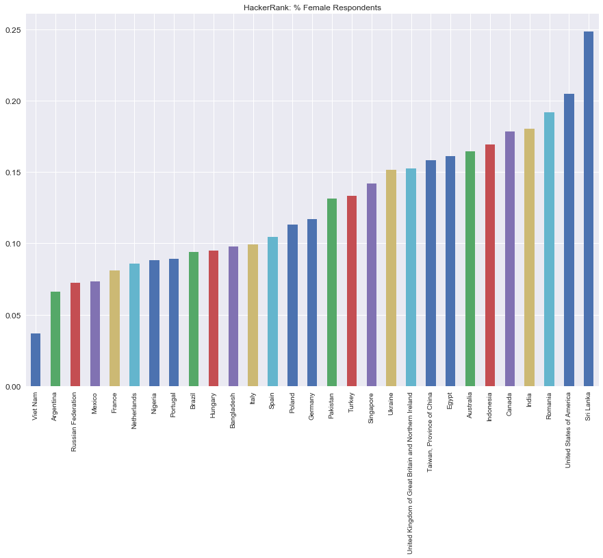

```python
plt.xticks(rotation=90)
female_share_countries = female_share.sort_values().plot(kind='bar',figsize=(15,10), title="HackerRank: % Female Respondents")


fig = female_share_countries.get_figure()
fig.savefig('HR_countries_female-share_barplot.jpg')
```

### Regional Total Respondents

```
Asia        14234
Americas     6675
Europe       3327
Africa        581
Oceania       204
Name: region, dtype: int64
```

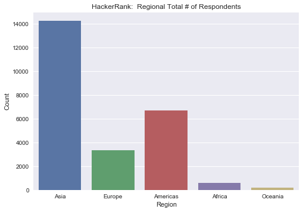

```python
# Regional Count

#print(values['CountryNumeric2'].value_counts())
print(values['region'].value_counts())

sns.set(font_scale=1)
count = sns.countplot(x='region', data=values)
count.set_xlabel('Region')
count.set_ylabel('Count')
count.set_title("HackerRank:  Regional Total # of Respondents")

fig = count.get_figure()
fig.savefig('HR_regional_total_barplot.jpg')
print("")
```

```python
## Before mapping, only use respondents that listed a country

only_names = values[(values["Country_Name"]!= "Not provided") & (values["Country_Name"]!= "Asia/Pacific Region") & (values["Country_Name"]!= "Europe")]
```

## Maps

#### Map of Total # of Respondents

```python
# Visualize by country

country = only_names['Country_Name'].value_counts()
#print(country)

# plotly
data = [dict(
    type ='choropleth',
    locations = country.index,
    locationmode ='country names',
    z = country.values,
    text = ('Count'+'<br>'),
    colorscale=[[0,"rgb(5, 10, 172)"],[0.35,"rgb(40, 60, 190)"],[0.5,"rgb(70, 100, 245)"],\
            [0.6,"rgb(90, 120, 245)"],[0.7,"rgb(106, 137, 247)"],[1,"rgb(220, 220, 220)"]],
    reversescale=True,
    marker=dict(line=dict(color='rgb(180,180,180)', width=0.5)),

    colorbar = dict(title ='HackerRank: Total Respondents by Country')
    )]

layout = dict(title = 'Number of respondents by country',
             geo = dict( showframe= False,
                       projection = dict(type = 'Mercator')))
fig = dict(data=data, layout=layout)
offline.plot(fig, filename= "HR_female_total.html", image_filename="HR_female_total",image='png')
print("Open this map: HR_female_total.png")
```

```
Open this map: HR_female_total.png
```

```python
### Map of Percent Female Respondents by Country

# plotly
data = [dict(
    type ='choropleth',
    locations = female_share.index,
    locationmode ='country names',
    z = female_share.values,
    text = '% female',
    colorscale=[[0,"rgb(5, 10, 172)"],[0.35,"rgb(40, 60, 190)"],[0.5,"rgb(70, 100, 245)"],\
            [0.6,"rgb(90, 120, 245)"],[0.7,"rgb(106, 137, 247)"],[1,"rgb(220, 220, 220)"]],
    reversescale=True,
    marker=dict(line=dict(color='rgb(180,180,180)', width=0.5)),
    colorbar = dict(title ='Response count')
    )]
layout = dict(title = 'HackerRank: Percent Female Response by Country',
             geo = dict( showframe= False,
                       showcoastlines=True,
                       projection = dict(type = 'Mercator')))
fig = dict(data=data, layout=layout)
offline.plot(fig, filename= "HR_female_percent.html", image_filename="HR_female_percent",image='png')
print("Open this map: HR_female_percent.png")
```

```
Open this map: HR_female_percent.png
```

```python
# Create new Dataframes for each region

asia = values[values["region"] == "Asia"]
americas  = values[values["region"] == "Americas"]
europe  = values[values["region"] == "Europe"]
africa  = values[values["region"] == "Africa"]
oceania  = values[values["region"] == "Oceania"]
```

```python
# Create new Dataframes for each Country case study

indonesia = values[values["Country_Name"] == "Indonesia"]
argentina  = values[values["Country_Name"] == "Argentina"]
south_africa  = values[values["Country_Name"] == "South Africa"]
pakistan  = values[values["Country_Name"] == "Pakistan"]
```

## Age and Years of Coding

```python
# Function for drawing heatmaps

def draw_heatmap(column1, column2, title=None, annot=True, ax=None, size=(10, 10), data=values):
    cross = pd.crosstab(data[column1], data[column2], normalize="columns")

    if ax is None:
        f, ax = plt.subplots(figsize=size)

    sns.heatmap(cross, cmap='Reds', fmt='g', annot=annot, ax=ax)
#    ax.set_ylabel(codebook.loc[column1]['question'])
    ax.set_xlabel(codebook.loc[column2]['question'])

    if title is not None:
        ax.set_title(title)
```

```python
# Fix age category data

# We need to shift NaN to 0, because data starts from value 1
numeric.loc[numeric['q1AgeBeginCoding'] == -1, 'q1AgeBeginCoding'] = 0
numeric.loc[numeric['q2Age'] == -1, 'q2Age'] = 0

# And to trim text so that it fits plots
numeric_mapping.loc['q2Age'] = [[i+1, j] for i, j in zip(range(9), ['Under 12', '12 - 18', '18 - 24', '25 - 34', '35 - 44', '45 - 54', '55 - 64', '65 - 74', '75+'])]

# Re-sort q1AgeBeginCoding list
#print(numeric_mapping.loc['q1AgeBeginCoding'])
#numeric_mapping.loc['q1AgeBeginCoding'] = pd.Categorical(numeric_mapping.loc['q1AgeBeginCoding'], ['5 - 10', '11 - 15', '16 - 20', '21 - 25', '26 - 30', '31 - 35', '36 - 40', '41 - 50'])

numeric_mapping.loc['q1AgeBeginCoding'] = numeric_mapping.loc['q1AgeBeginCoding'].applymap(lambda x: str(x).replace('years old', ''))
```

```python
## Create male/female dataframes, for heatmapping

women = values[values["q3Gender"]=="Female"]
men = values[values["q3Gender"]=="Male"]
```

### Age and Years of Coding, by Gender

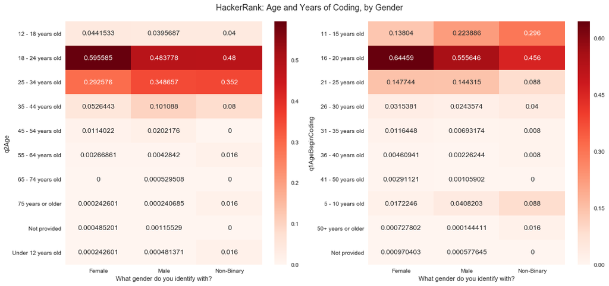

```python
# Age and Age Started Coding

fig, ax = plt.subplots(nrows=1, ncols=2, figsize=(15,7))

sns.set()
draw_heatmap('q2Age', 'q3Gender', ax=ax[0], annot=True, data=values)
draw_heatmap('q1AgeBeginCoding', 'q3Gender', ax=ax[1], annot=True, data=values)

fig.suptitle("HackerRank: Age and Years of Coding, by Gender")

fig.tight_layout()
plt.subplots_adjust(top=0.92)

plt.savefig('HR_age_years-coding_gender.jpg')
```

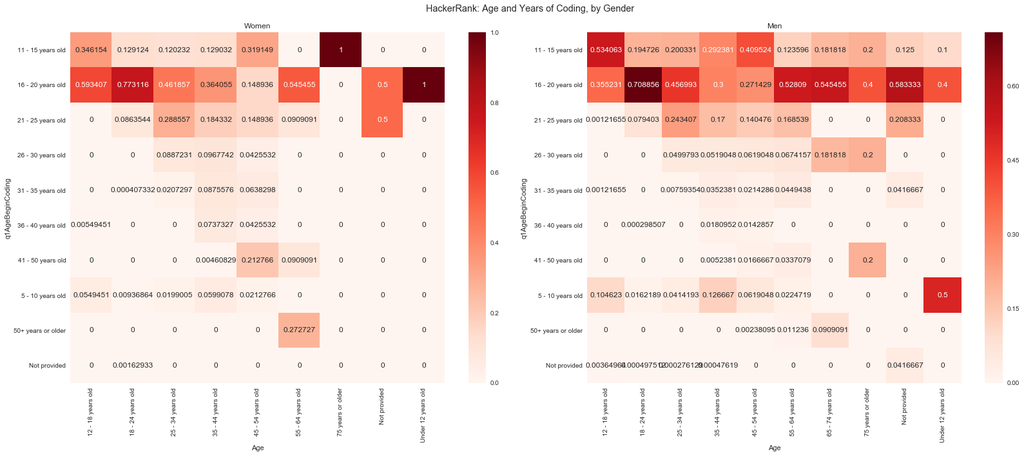

```python
# Age and Age Started Coding, by Gender

fig, ax = plt.subplots(nrows=1, ncols=2, figsize=(23,10))
fig.suptitle("HackerRank: Age and Years of Coding, by Gender")

sns.set()

draw_heatmap('q1AgeBeginCoding', 'q2Age', ax=ax[0], annot=True, data=women)
ax[0].set_xlabel("Age")
ax[0].set_ylabel("q1AgeBeginCoding")
ax[0].set_title('Women')

draw_heatmap('q1AgeBeginCoding', 'q2Age', ax=ax[1], annot=True, data=men)
ax[1].set_xlabel("Age")
ax[1].set_ylabel("q1AgeBeginCoding")
ax[1].set_title('Men')


fig.tight_layout()
plt.subplots_adjust(top=0.92)

plt.savefig('HR_age_years-coding_gender_combined.jpg')
```

### TODO: Add Age and Years of Coding, by Region

## Education

### Education, by Gender

```
Q: What is the highest level of education you have (or plan to obtain)?
```

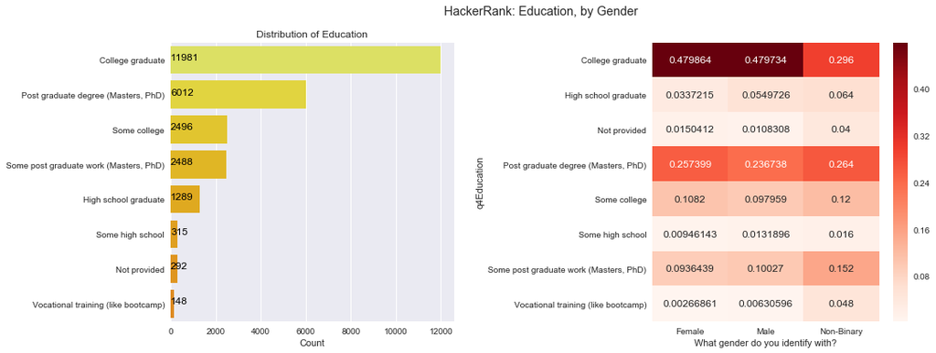

```python
# Education level

print('Q:',codebook.loc['q4Education']['question'],"\n")

f,ax = plt.subplots(1,2, figsize=(16,6))



st_age = values['q4Education'].value_counts()
sns.barplot(st_age.values, st_age.index, palette='Wistia',ax=ax[0])
ax[0].set_title('Distribution of Education')
ax[0].set_xlabel('Count')
for i, v in enumerate(st_age.values):
    ax[0].text(0.8,i,v,color='k',fontsize=12)


sns.set()
draw_heatmap('q4Education', 'q3Gender', ax=ax[1], annot=True)


plt.subplots_adjust(wspace=0.7)

plt.suptitle("HackerRank: Education, by Gender")


plt.savefig('HR_education_gender.jpg')
```

### Education, by Gender and Region

```
Q: What is the highest level of education you have (or plan to obtain)?
```

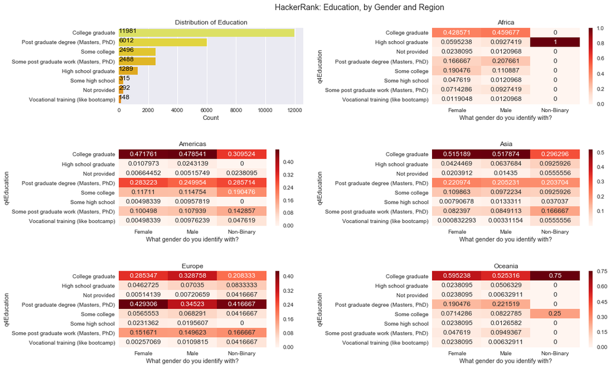

```python
# Education level

print('Q:',codebook.loc['q4Education']['question'],"\n")

f,ax = plt.subplots(3,2, figsize=(16,10))


st_age = values['q4Education'].value_counts()
sns.barplot(st_age.values, st_age.index, palette='Wistia',ax=ax[0][0])
ax[0][0].set_title('Distribution of Education')
ax[0][0].set_xlabel('Count')
for i, v in enumerate(st_age.values):
    ax[0][0].text(0.8,i,v,color='k',fontsize=12)


sns.set()
draw_heatmap('q4Education', 'q3Gender', ax=ax[0][1], annot=True, data=africa)
ax[0][1].set_title('Africa')

sns.set()
draw_heatmap('q4Education', 'q3Gender', ax=ax[1][0], annot=True, data=americas)
ax[1][0].set_title('Americas')

sns.set()
draw_heatmap('q4Education', 'q3Gender', ax=ax[1][1], annot=True, data=asia)
ax[1][1].set_title('Asia')

sns.set()
draw_heatmap('q4Education', 'q3Gender', ax=ax[2][0], annot=True, data=europe)
ax[2][0].set_title('Europe')

sns.set()
draw_heatmap('q4Education', 'q3Gender', ax=ax[2][1], annot=True, data=oceania)
ax[2][1].set_title('Oceania')

plt.subplots_adjust(hspace=0.6, wspace=0.7, top=0.92)


plt.suptitle("HackerRank: Education, by Gender and Region")
plt.savefig('HR_education_gender_region.jpg')
```

### Total respondents for 4 Countries

```python
print("Argentina:", len(argentina), "\nIndonesia:", len(indonesia), "\nSouth Africa:", len(south_africa), "\nPakistan", len(pakistan))
```

```
Argentina: 106
Indonesia: 386
South Africa: 96
Pakistan 138
```

### Education, by Gender, for 4 Countries

```
Q: What is the highest level of education you have (or plan to obtain)?
```

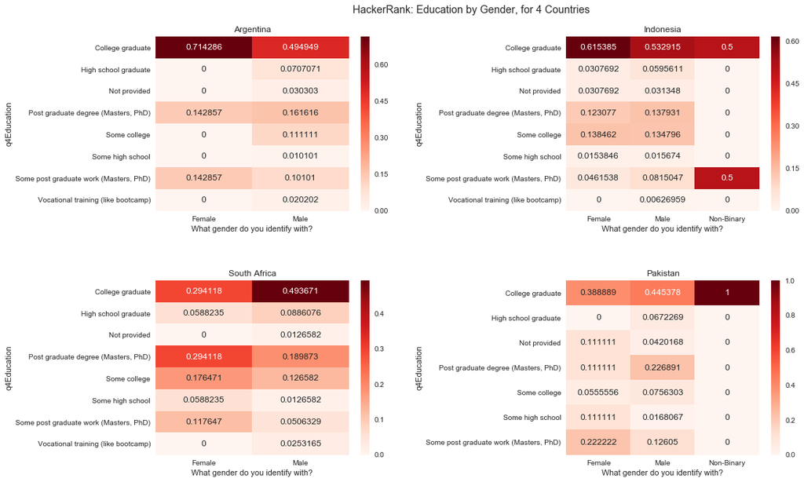

```python
# Education level

print('Q:',codebook.loc['q4Education']['question'],"\n")

f,ax = plt.subplots(2,2, figsize=(16,10))

question = 'q4Education'

sns.set()
draw_heatmap(question, 'q3Gender', ax=ax[0][0], annot=True, data=argentina)
ax[0][0].set_title('Argentina')

sns.set()
draw_heatmap(question, 'q3Gender', ax=ax[0][1], annot=True, data=indonesia)
ax[0][1].set_title('Indonesia')

sns.set()
draw_heatmap(question, 'q3Gender', ax=ax[1][0], annot=True, data=south_africa)
ax[1][0].set_title('South Africa')

sns.set()
draw_heatmap(question, 'q3Gender', ax=ax[1][1], annot=True, data=pakistan)
ax[1][1].set_title('Pakistan')



plt.suptitle("HackerRank: Education by Gender, for 4 Countries")

plt.subplots_adjust(hspace=0.4, wspace=0.7, top=0.92)
plt.savefig('HR_education_gender_4countries.jpg')
```

## Industry

### Industry, by Gender

```
Q: Which best describes the industry you work in?
```

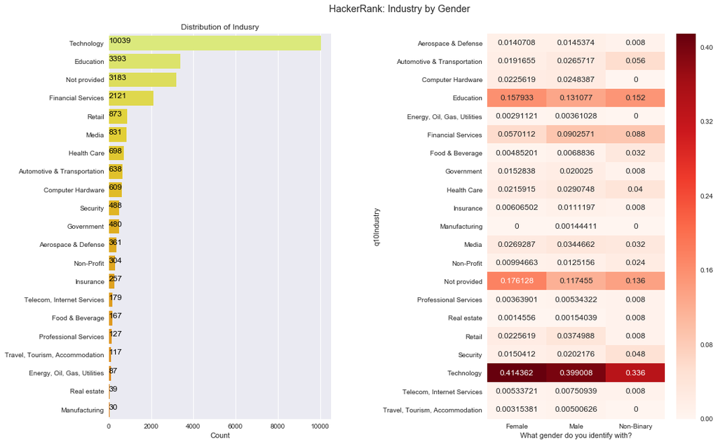

```python
# Industry

print('Q:',codebook.loc['q10Industry']['question'],"\n")

f,ax = plt.subplots(1,2,figsize=(16,10))
ind = values['q10Industry'].value_counts()
sns.barplot(ind.values, ind.index, palette='Wistia',ax=ax[0])
ax[0].set_title('Distribution of Indusry')
ax[0].set_xlabel('Count')
for i, v in enumerate(ind.values):
    ax[0].text(0.8,i,v,color='k',fontsize=12)


sns.set()
draw_heatmap('q10Industry', 'q3Gender', ax=ax[1], annot=True)
plt.subplots_adjust(wspace=0.7, top=0.92);

plt.suptitle("HackerRank: Industry by Gender")
plt.savefig('HR_industry_gender.jpg')
```

### Industry, by Gender and Region

```
Q: Which best describes the industry you work in?
```

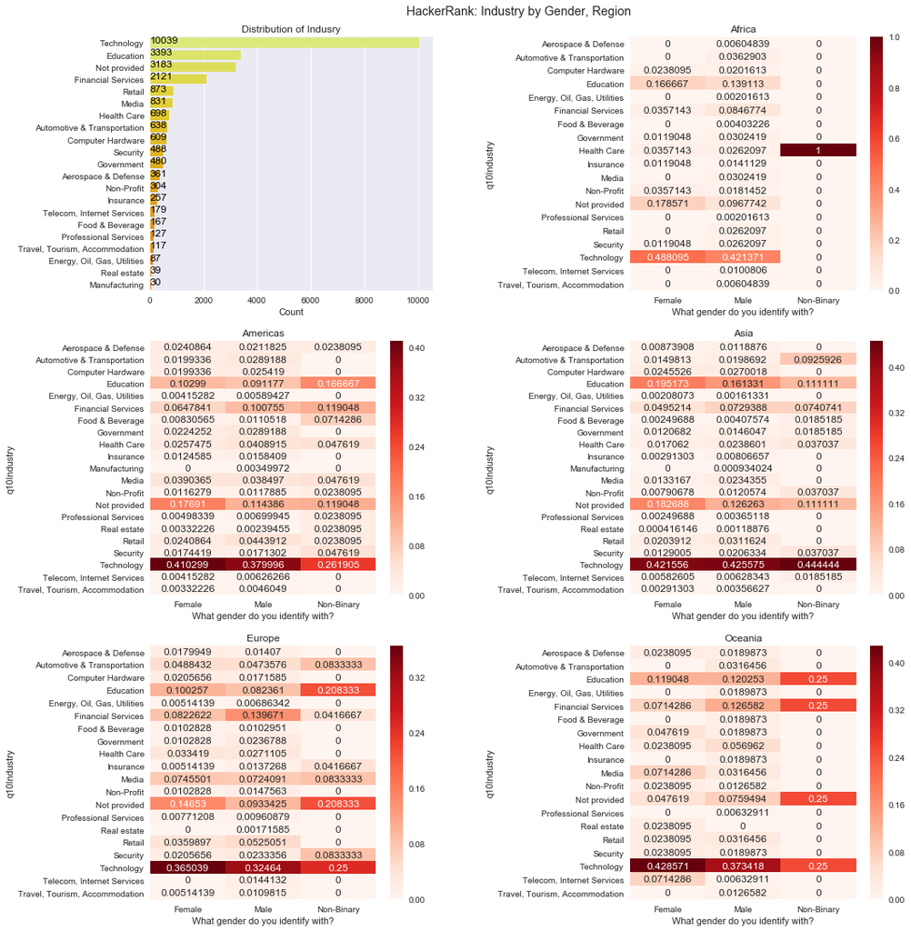

```python
# Industry

print('Q:',codebook.loc['q10Industry']['question'],"\n")

f,ax = plt.subplots(3,2,figsize=(16,17))


ind = values['q10Industry'].value_counts()
sns.barplot(ind.values, ind.index, palette='Wistia',ax=ax[0][0])
ax[0][0].set_title('Distribution of Indusry')
ax[0][0].set_xlabel('Count')
for i, v in enumerate(ind.values):
    ax[0][0].text(0.8,i,v,color='k',fontsize=12)

question = 'q10Industry'

sns.set()
draw_heatmap(question, 'q3Gender', ax=ax[0][1], annot=True, data=africa)
ax[0][1].set_title('Africa')

sns.set()
draw_heatmap(question, 'q3Gender', ax=ax[1][0], annot=True, data=americas)
ax[1][0].set_title('Americas')

sns.set()
draw_heatmap(question, 'q3Gender', ax=ax[1][1], annot=True, data=asia)
ax[1][1].set_title('Asia')

sns.set()
draw_heatmap(question, 'q3Gender', ax=ax[2][0], annot=True, data=europe)
ax[2][0].set_title('Europe')

sns.set()
draw_heatmap(question, 'q3Gender', ax=ax[2][1], annot=True, data=oceania)
ax[2][1].set_title('Oceania')


plt.subplots_adjust(wspace=0.7, top=0.95);

plt.suptitle("HackerRank: Industry by Gender, Region")
plt.savefig('HR_industry_gender_region.jpg')
```

### Industry, by Gender, for 4 Countries

```
Q: Which best describes the industry you work in?
```

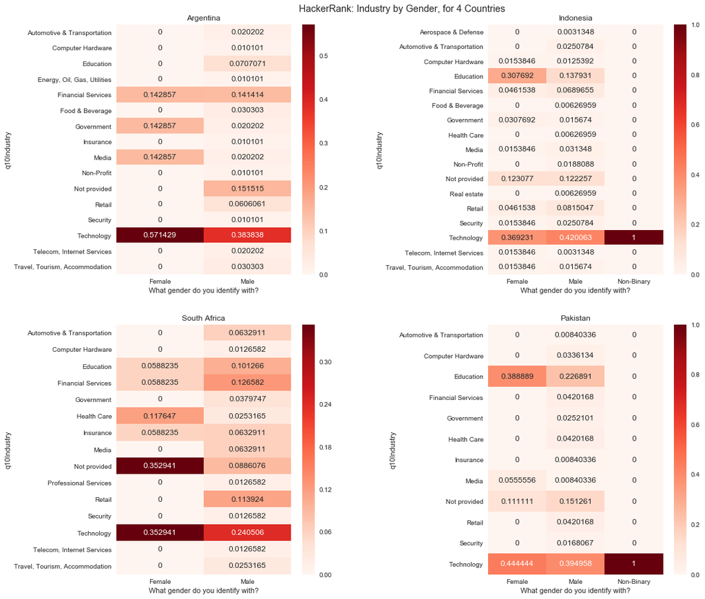

```python
# Industry

print('Q:',codebook.loc['q10Industry']['question'],"\n")

f,ax = plt.subplots(2,2,figsize=(16,14))

question = 'q10Industry'

sns.set()
draw_heatmap(question, 'q3Gender', ax=ax[0][0], annot=True, data=argentina)
ax[0][0].set_title('Argentina')

sns.set()
draw_heatmap(question, 'q3Gender', ax=ax[0][1], annot=True, data=indonesia)
ax[0][1].set_title('Indonesia')

sns.set()
draw_heatmap(question, 'q3Gender', ax=ax[1][0], annot=True, data=south_africa)
ax[1][0].set_title('South Africa')

sns.set()
draw_heatmap(question, 'q3Gender', ax=ax[1][1], annot=True, data=pakistan)
ax[1][1].set_title('Pakistan')

plt.subplots_adjust(wspace=0.7, top=0.95)

plt.suptitle("HackerRank: Industry by Gender, for 4 Countries")
plt.savefig('HR_industry_gender_4countries.jpg')
```

## Job Level

### Job Level, by Gender

```
Q: Which of the following best matches your employment level?
```

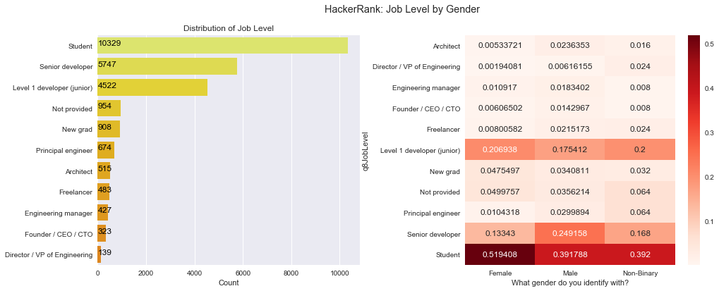

```python
# Job Level

print('Q:',codebook.loc['q8JobLevel']['question'],"\n")

f,ax = plt.subplots(1,2,figsize=(16,6))
job = values['q8JobLevel'].value_counts()
sns.barplot(job.values, job.index, palette='Wistia',ax=ax[0])
ax[0].set_xlabel('Count')
ax[0].set_title('Distribution of Job Level')
for i, v in enumerate(job.values):
    ax[0].text(0.8,i,v,color='k',fontsize=12)


sns.set()
draw_heatmap('q8JobLevel', 'q3Gender', ax=ax[1], annot=True)
plt.subplots_adjust(wspace=0.4);


plt.suptitle("HackerRank: Job Level by Gender")
fig.tight_layout()

plt.savefig('HR_joblevel_gender.jpg')
```

### Job Level, by Gender and Region

```
Q: Which of the following best matches your employment level?
```

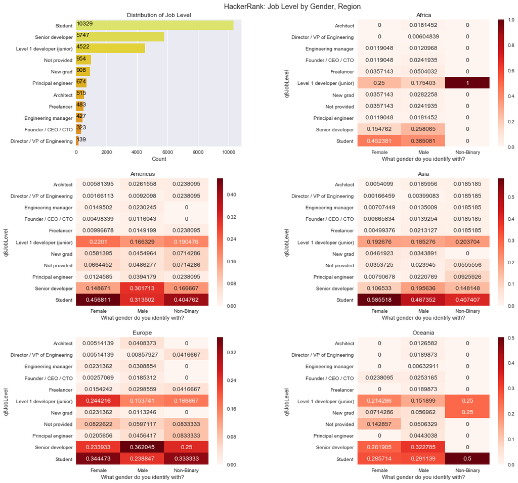

```python
# Job Level

print('Q:',codebook.loc['q8JobLevel']['question'],"\n")

f,ax = plt.subplots(3,2,figsize=(16,15))
job = values['q8JobLevel'].value_counts()
sns.barplot(job.values, job.index, palette='Wistia',ax=ax[0][0])
ax[0][0].set_xlabel('Count')
ax[0][0].set_title('Distribution of Job Level')
for i, v in enumerate(job.values):
    ax[0][0].text(0.8,i,v,color='k',fontsize=12)


question = 'q8JobLevel'

sns.set()
draw_heatmap(question, 'q3Gender', ax=ax[0][1], annot=True, data=africa)
ax[0][1].set_title('Africa')

sns.set()
draw_heatmap(question, 'q3Gender', ax=ax[1][0], annot=True, data=americas)
ax[1][0].set_title('Americas')

sns.set()
draw_heatmap(question, 'q3Gender', ax=ax[1][1], annot=True, data=asia)
ax[1][1].set_title('Asia')

sns.set()
draw_heatmap(question, 'q3Gender', ax=ax[2][0], annot=True, data=europe)
ax[2][0].set_title('Europe')

sns.set()
draw_heatmap(question, 'q3Gender', ax=ax[2][1], annot=True, data=oceania)
ax[2][1].set_title('Oceania')


plt.subplots_adjust(hspace=0.25, wspace=0.7, top=0.95)


plt.suptitle("HackerRank: Job Level by Gender, Region")
fig.tight_layout()

plt.savefig('HR_joblevel_gender_region.jpg')
```

### Job Level, by Gender, for 4 Countries

```
Q: Which of the following best matches your employment level?
```

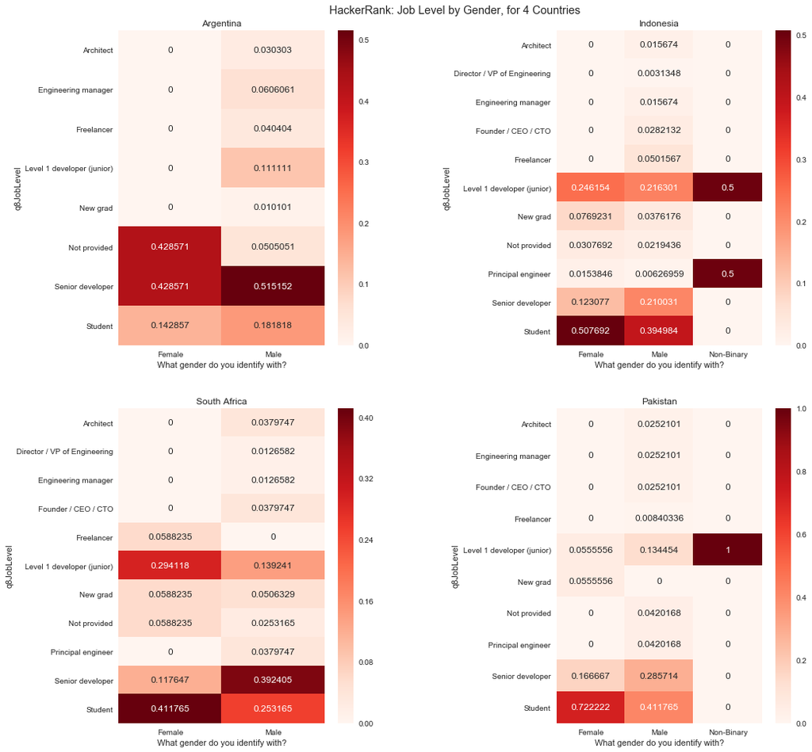

```python
# Job Level

print('Q:',codebook.loc['q8JobLevel']['question'], "\n")

f,ax = plt.subplots(2,2,figsize=(16,15))

question = 'q8JobLevel'

sns.set()
draw_heatmap(question, 'q3Gender', ax=ax[0][0], annot=True, data=argentina)
ax[0][0].set_title('Argentina')

sns.set()
draw_heatmap(question, 'q3Gender', ax=ax[0][1], annot=True, data=indonesia)
ax[0][1].set_title('Indonesia')

sns.set()
draw_heatmap(question, 'q3Gender', ax=ax[1][0], annot=True, data=south_africa)
ax[1][0].set_title('South Africa')

sns.set()
draw_heatmap(question, 'q3Gender', ax=ax[1][1], annot=True, data=pakistan)
ax[1][1].set_title('Pakistan')


plt.subplots_adjust(hspace=0.2, wspace=0.7, top=0.95)


plt.suptitle("HackerRank: Job Level by Gender, for 4 Countries")

plt.savefig('HR_joblevel_gender_4countries.jpg')
```

### Map of Percent Senior Developers, by Gender

```python
# Share of female senior developers by country

senior_dev = only_names[only_names['q8JobLevel'] == 'Senior developer']

female = senior_dev[senior_dev['q3Gender'] == 'Female']['Country_Name'].value_counts()
male = senior_dev[senior_dev['q3Gender'] == 'Male']['Country_Name'].value_counts()

country_share = (female/(female+male)).dropna()

# plotly
data = [dict(
    type ='choropleth',
    locations = country_share.index,
    locationmode ='country names',
    z = country_share.values,
    text = '% female',
    colorscale=[[0,"rgb(5, 10, 172)"],[0.35,"rgb(40, 60, 190)"],[0.5,"rgb(70, 100, 245)"],\
            [0.6,"rgb(90, 120, 245)"],[0.7,"rgb(106, 137, 247)"],[1,"rgb(220, 220, 220)"]],
    reversescale=True,
    marker=dict(line=dict(color='rgb(180,180,180)', width=0.5)),
    colorbar = dict(title ='Response count')
    )]
layout = dict(title = 'HackerRank: Percent of Female Senior Developers',
             geo = dict( showframe= False,
                       showcoastlines=True,
                       projection = dict(type = 'Mercator')))
fig = dict(data=data, layout=layout)
offline.plot(fig, filename= "HR_female_percent_senior.html", image_filename="HR_female_percent_senior",image='png')
print("Open this map: HR_female_percent_senior.png")
```

```
Open this map: HR_female_percent_senior.png
```

## Hiring Managers

### Hiring Managers, by Gender

```
Q?: Do you interview people as part of your company's hiring process?
```

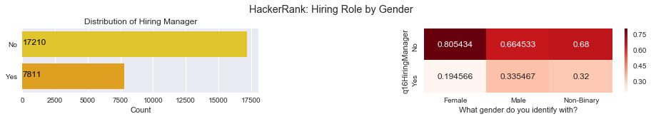

```python
# Hiring Managers

print('Q?:',codebook.loc['q16HiringManager']['question'])

f,ax = plt.subplots(1,2,figsize=(16,2))
hm = values['q16HiringManager'].value_counts()
sns.barplot(hm.values, hm.index, palette='Wistia',ax=ax[0])
ax[0].set_title('Distribution of Hiring Manager')
ax[0].set_xlabel('Count')

for i, v in enumerate(hm.values):
    ax[0].text(0.8,i,v,color='k',fontsize=12)


sns.set()
draw_heatmap('q16HiringManager', 'q3Gender', ax=ax[1], annot=True)
plt.subplots_adjust(wspace=0.7, top=0.75)


plt.suptitle("HackerRank: Hiring Role by Gender")

plt.savefig('HR_hiring_gender.jpg')
```

### Hiring Managers, by Gender and Region

```
Q: Do you interview people as part of your company's hiring process?
```

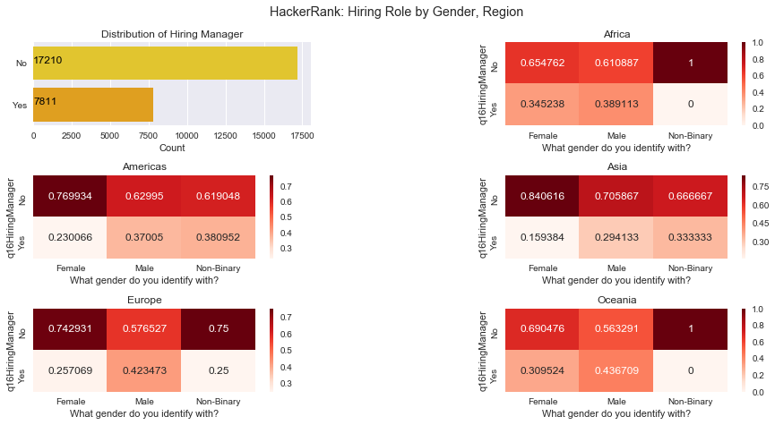

```python
# Hiring Managers by region

print('Q:',codebook.loc['q16HiringManager']['question'], "\n")

f,ax = plt.subplots(3,2,figsize=(15,7))
hm = values['q16HiringManager'].value_counts()
sns.barplot(hm.values, hm.index, palette='Wistia',ax=ax[0][0])
ax[0][0].set_title('Distribution of Hiring Manager')
ax[0][0].set_xlabel('Count')

for i, v in enumerate(hm.values):
    ax[0][0].text(0.8,i,v,color='k',fontsize=12)

question = 'q16HiringManager'

sns.set()
draw_heatmap(question, 'q3Gender', ax=ax[0][1], annot=True, data=africa)
ax[0][1].set_title('Africa')

sns.set()
draw_heatmap(question, 'q3Gender', ax=ax[1][0], annot=True, data=americas)
ax[1][0].set_title('Americas')

sns.set()
draw_heatmap(question, 'q3Gender', ax=ax[1][1], annot=True, data=asia)
ax[1][1].set_title('Asia')

sns.set()
draw_heatmap(question, 'q3Gender', ax=ax[2][0], annot=True, data=europe)
ax[2][0].set_title('Europe')

sns.set()
draw_heatmap(question, 'q3Gender', ax=ax[2][1], annot=True, data=oceania)
ax[2][1].set_title('Oceania')

plt.subplots_adjust(hspace=0.6, wspace=0.7, top=0.90)


plt.suptitle("HackerRank: Hiring Role by Gender, Region")

plt.savefig('HR_hiring_gender_region.jpg')
```

### Hiring Managers, by Gender, for 4 Countries

```
Q: Do you interview people as part of your company's hiring process?
```

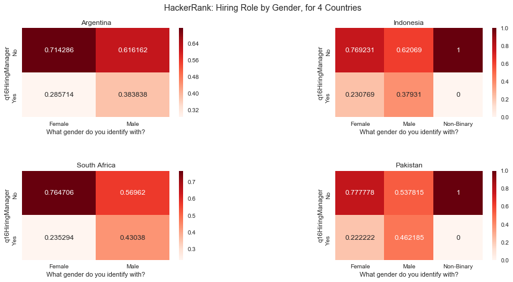

```python
# Hiring Managers

print('Q:',codebook.loc['q16HiringManager']['question'], "\n")

f,ax = plt.subplots(2,2,figsize=(15,7))



question = 'q16HiringManager'

sns.set()
draw_heatmap(question, 'q3Gender', ax=ax[0][0], annot=True, data=argentina)
ax[0][0].set_title('Argentina')

sns.set()
draw_heatmap(question, 'q3Gender', ax=ax[0][1], annot=True, data=indonesia)
ax[0][1].set_title('Indonesia')

sns.set()
draw_heatmap(question, 'q3Gender', ax=ax[1][0], annot=True, data=south_africa)
ax[1][0].set_title('South Africa')

sns.set()
draw_heatmap(question, 'q3Gender', ax=ax[1][1], annot=True, data=pakistan)
ax[1][1].set_title('Pakistan')


plt.subplots_adjust(hspace=0.6, wspace=0.7, top=0.90)


plt.suptitle("HackerRank: Hiring Role by Gender, for 4 Countries")

plt.savefig('HR_hiring_gender_4countries.jpg')
```

### Map of Percent Hiring Managers, by Gender

```python
# Map of share of female hiring managers


hiring_managers = only_names[only_names['q16HiringManager'] == 'Yes']

female = hiring_managers[hiring_managers['q3Gender'] == 'Female']['Country_Name'].value_counts()
male = hiring_managers[hiring_managers['q3Gender'] == 'Male']['Country_Name'].value_counts()

country_share = (female/(female+male)).dropna()

# plotly
data = [dict(
    type ='choropleth',
    locations = country_share.index,
    locationmode ='country names',
    z = country_share.values,
    text = '% female',
    colorscale=[[0,"rgb(5, 10, 172)"],[0.35,"rgb(40, 60, 190)"],[0.5,"rgb(70, 100, 245)"],\
            [0.6,"rgb(90, 120, 245)"],[0.7,"rgb(106, 137, 247)"],[1,"rgb(220, 220, 220)"]],
    reversescale=True,
    marker=dict(line=dict(color='rgb(180,180,180)', width=0.5)),
    colorbar = dict(title ='Response count')
    )]
layout = dict(title = 'HackerRank: Percent of Female Hiring Managers',
             geo = dict( showframe= False,
                       showcoastlines=True,
                       projection = dict(type = 'Mercator')))
fig = dict(data=data, layout=layout)

offline.plot(fig, filename= "HR_female_percent_hiring.html", image_filename="HR_female_percent_hiring",image='png')
print("Open this map: HR_female_percent_hiring.png")
```

```
Open this map: HR_female_percent_hiring.png
```